# STAT312: Practical 01

26 July 2024

## `rmdNMU`’s `Practical` Template

The `Practical` template in the `rmdNMU` package is intended for R practicals. Lecturers should complete the appropriate information in the `YAML` section at the top of the file and write questions/instructions for students in the body of the file. See the following short guide on using R Markdown. Alternatively, consult the resources on the [R Markdown website](https://rmarkdown.rstudio.com/docs/articles/rmarkdown.html).

## R Markdown: A Brief Overview

**R Markdown** is a powerful tool that allows you to create dynamic documents that seamlessly integrate code, its output (like graphs and tables), and explanatory text. This makes it ideal for data analysis, reporting, and sharing results.

### Basic Markdown Syntax

Markdown is a lightweight markup language, meaning you use simple symbols to format your text. Here are some common examples:

- **Headers:**
  - `# H1` for largest header
  - `## H2` for smaller header
  - `### H3` and so on
- **Emphasis:**
  - *italics*
  - **bold**
- **Lists:**
  - Unordered: `* item`
  - Ordered: `1. item`
- **Links:**
  - `[link text](link url)`
- **Images:**
  - `![alt text](image path)`

### Embedding R Code

To include R code in your R Markdown document, enclose your code with three backticks (```). These are known as *code chunks*. Here is an example of an unnamed code code chunk.

```r
# This code chunk will show both the code and result from executing code.
the_answer <- 37 + sqrt(5^2)
the_answer
```

```
## [1] 42
```

When you “knit” your R Markdown document (convert it to another format like HTML, PDF, or Word), the R code within these chunks is executed, and the results are incorporated into the final document.

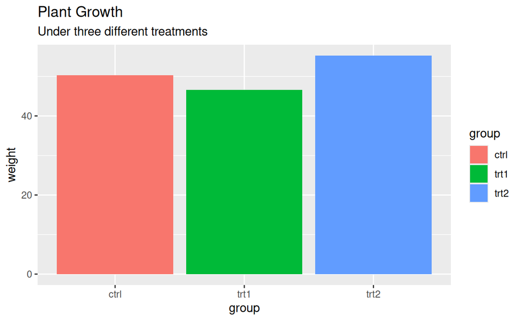

It is also possible to include in line code. For example, remember that `the_answer` was 42.